# Ejemplo_Fake2

# Presentación

En este post mostraré qué está afectando el desempeño en la educación cívica en el Perú, a nivel de sus provincias; según datos del 2017. Así hemos partido por proponer que la educación cívica es afectada por el nivel de habilidades escolares, por la relevancia estratégica de la provincia, y por su estabilidad psicológica de los alumnos.

Los datos están organizados así:

[interactive chart not shown]

# Situación Regional

Veamos la situación regional desde el comportamiento de las variables independientes, utilizando análisis de clusters, siguiendo la técnica jerárquica.

El primer paso es preparar los datos para el análisis cluster.

```r
rm(list = ls())
# carga de datos
link='https://docs.google.com/spreadsheets/d/e/2PACX-1vQLNWEPcKqxX99PZi8rzvBLM9r0pI_z8O7tFSrbbps0MNF3F66sE90F6d9wNEnmxTZXi5zBQLy51prn/pub?gid=0&single=true&output=csv'
LosDatos=read.csv(link)

# variables a selecionar
varsHabi=c("LEC","ESC","MAT","CIE")
varsRelev=c("capital_depa","es_frontera","costa")
varsPsi=c("LOCUS","CONCPT","MOT")

# cambiar texto a numero
a_0_1=function(x){ifelse(x=='no',0,1)}
LosDatos[,varsRelev]=lapply(LosDatos[,varsRelev],a_0_1)
```

Revisemos los rangos de la data numerica:

```r
summary(LosDatos[,c(varsHabi,varsPsi)])
```

```
##       LEC             ESC             MAT             CIE
##  Min.   :28.30   Min.   :25.50   Min.   :32.70   Min.   :26.00
##  1st Qu.:41.60   1st Qu.:41.10   1st Qu.:41.88   1st Qu.:39.00
##  Median :47.90   Median :48.90   Median :46.60   Median :47.10
##  Mean   :49.59   Mean   :49.69   Mean   :49.14   Mean   :47.89
##  3rd Qu.:56.52   3rd Qu.:56.70   3rd Qu.:56.65   3rd Qu.:56.30
##  Max.   :76.00   Max.   :67.10   Max.   :75.50   Max.   :71.50
##      LOCUS              CONCPT              MOT
##  Min.   :-2.23000   Min.   :-2.62000   Min.   :0.0000
##  1st Qu.:-0.41250   1st Qu.:-0.30250   1st Qu.:0.3300
##  Median : 0.07000   Median : 0.03000   Median :0.6700
##  Mean   : 0.03908   Mean   : 0.03587   Mean   :0.6669
##  3rd Qu.: 0.47250   3rd Qu.: 0.59000   3rd Qu.:1.0000
##  Max.   : 1.36000   Max.   : 1.19000   Max.   :1.0000
```

La data de “varsHabi” debe ser estandarizada como “varsPsi”:

```r
LosDatos[,c(varsHabi)]=scale(LosDatos[,c(varsHabi)])
```

Luego obtendremos los tres clusters sugeridos usando la técnica jerarquica aglomerativa (ver anexo 1):

```r
# subset para clusterizar
paraCluster=LosDatos[,c(varsHabi,varsRelev,varsPsi)]


# cambio de nombre de fila
row.names(paraCluster)=LosDatos$PROVINCIA_2
```

```r
library(cluster)
library(factoextra)
set.seed(123)
g.dist = daisy(paraCluster, metric="gower")
res.agnes <- hcut(g.dist, k = 3,hc_func='agnes')
paraCluster$agnes=res.agnes$cluster
```

Para cada cluster, este es el comportamiento de las variables numericas:

```r
aggregate(data=paraCluster[,-c(5:7)],.~agnes,FUN=mean)
```

| agnes | LEC | ESC | MAT | CIE | LOCUS | CONCPT | MOT |
| --- | --- | --- | --- | --- | --- | --- | --- |
| 1 | 0.06947983 | -0.042790808 | -0.03794286 | -0.02265268 | 0.04115385 | 0.29153846 | 0.7569231 |
| 2 | -0.01953072 | 0.009581716 | 0.02411213 | -0.01117949 | 0.01251748 | -0.01132867 | 0.6435664 |
| 3 | 0.03653397 | -0.009541642 | -0.09116740 | 0.08102358 | 0.17777778 | 0.03962963 | 0.7040741 |

Podemos recodificar estas variables:

```r
paraCluster$agnes=dplyr::recode(paraCluster$agnes, `1` = 3, `2`=1,`3`=2)
paraCluster$agnes=as.ordered(paraCluster$agnes)
```

El **dendograma** nos muestra el proceso de conglomeración:

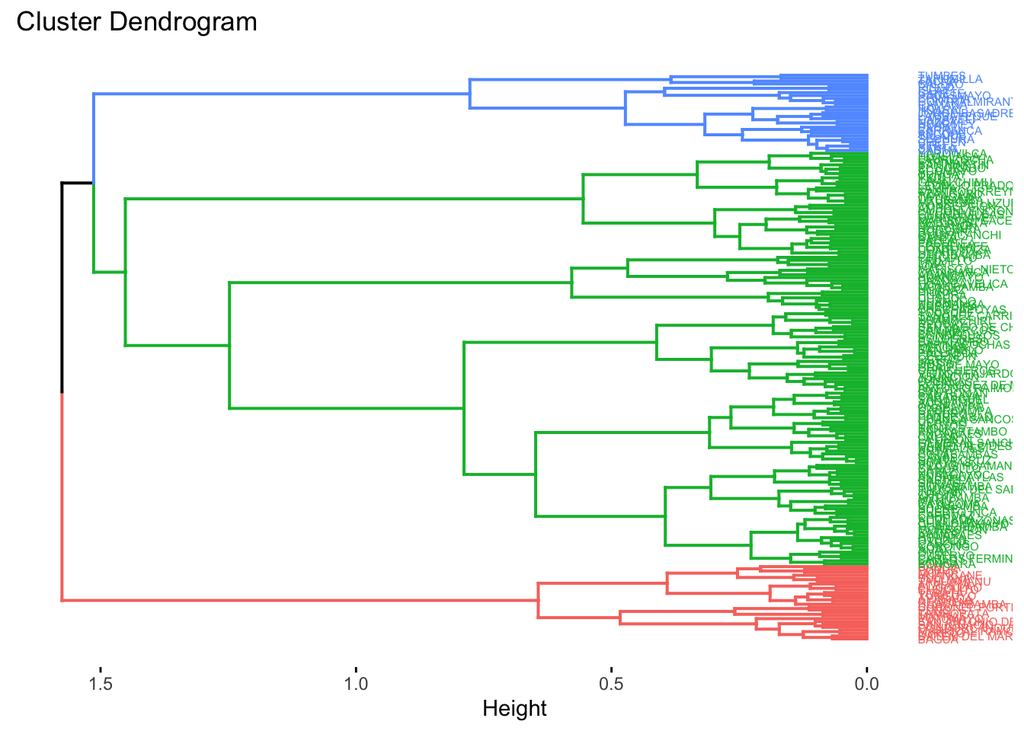

```r
# Visualize
fviz_dend(res.agnes, cex = 0.4, horiz = T)
```

Una primera mirada a las provincias del Perú sería:

```r
library(sf)
```

```r
linkMapa='https://github.com/PoliticayGobiernoPUCP/data/raw/master/PROVINCIAS_peru.json'
mapaProv=read_sf(linkMapa)

paraCluster$PROVINCIA=row.names(paraCluster)
mapaProv=merge(mapaProv,paraCluster, by="PROVINCIA")
```

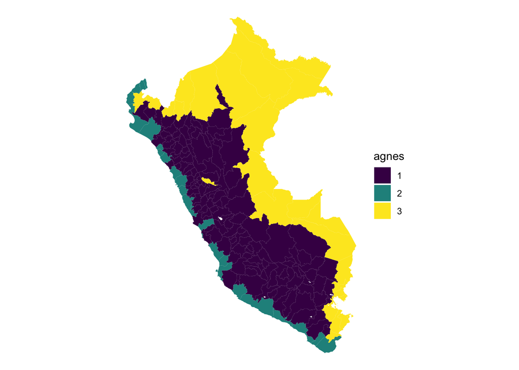

```r
library(ggplot2)

base= ggplot(data=mapaProv) + theme_void()
base + geom_sf(aes(fill=agnes), color=NA)
```

# Preparación de latentes

```r
model <- ' habilidad  =~ LEC + ESC + MAT + CIE
           estabilidad =~ LOCUS + CONCPT + MOT'
```

Ahora vemos qué arroja el modelo:

```r
#sigamos
library(lavaan)
cfa_fit <- cfa(model, data=LosDatos,
           std.lv=TRUE,
           missing="fiml")
```

Preparo los tests:

```r
allParamCFA=parameterEstimates(cfa_fit,standardized = T)
allFitCFA=as.list(fitMeasures(cfa_fit))
```

Veamos resultados:

- Si cada indicador tiene una buena conexión con su latente (ver p valor):

```r
allParamCFA[allParamCFA$op=="=~",c("lhs","rhs","pvalue","std.all")]
```

|  | lhs | rhs | pvalue | std.all |
| --- | --- | --- | --- | --- |
| 1 | habilidad | LEC | 0.000000000 | 0.8866226 |
| 2 | habilidad | ESC | 0.000000000 | 0.7954093 |
| 3 | habilidad | MAT | 0.000000000 | 0.8338976 |
| 4 | habilidad | CIE | 0.000000000 | 0.8186193 |
| 5 | estabilidad | LOCUS | 0.038387512 | 0.2024849 |
| 6 | estabilidad | CONCPT | 0.002519132 | 0.4873920 |
| 7 | estabilidad | MOT | 0.001411014 | 0.7746450 |

Averigüemos qué tan bien salió el modelo:

- El ChiSquare es NO significativo? (p_value debe ser mayor a 0.05 para que sea bueno)

```r
allFitCFA[c("chisq", "df", "pvalue")] # pvalue>0.05
```

```
## $chisq
## [1] 8.552672
##
## $df
## [1] 13
##
## $pvalue
## [1] 0.805827
```

- El Índice Tucker Lewi es mayor a 0.9?

```r
allFitCFA$tli # > 0.90
```

```
## [1] 1.014137
```

- La Raíz del error cuadrático medio de aproximación es menor a 0.05?

```r
allFitCFA[c('rmsea.ci.lower','rmsea' ,'rmsea.ci.upper')]
```

```
## $rmsea.ci.lower
## [1] 0
##
## $rmsea
## [1] 0
##
## $rmsea.ci.upper
## [1] 0.04554035
```

Cuales son los scores:

```r
lavPredict(cfa_fit)
```

[output not shown]

[output cut: 182 more lines]

```r
allScores=as.data.frame(lavPredict(cfa_fit))
library(BBmisc)
LosDatos$habilidad=normalize(allScores$habilidad,
                    method = "range",
                    margin=2, # by column
                    range = c(0, 100))
LosDatos$estabilidad=normalize(allScores$estabilidad,
                    method = "range",
                    margin=2, # by column
                    range = c(0, 100))
```

La variable latente estratégica la calcularemos creando un indicador sumativo:

```r
LosDatos$relevancia=apply(LosDatos[,varsRelev],1,sum)
LosDatos$relevancia=as.ordered(LosDatos$relevancia)
```

# Regresión y prueba de hipotesis

```r
hipotesis=formula(CIV ~ habilidad + relevancia + estabilidad + pob)

resultado=lm(hipotesis,data = LosDatos)
summary(resultado)
```

```
##
## Call:
## lm(formula = hipotesis, data = LosDatos)
##
## Residuals:
##      Min       1Q   Median       3Q      Max
## -23.9541  -4.3162  -0.0553   4.7695  16.3622
##
## Coefficients:
##                Estimate Std. Error t value Pr(>|t|)
## (Intercept)   3.552e+01  2.034e+00  17.462  < 2e-16 ***
## habilidad     2.795e-01  1.951e-02  14.325  < 2e-16 ***
## relevancia.L -9.201e+00  3.352e+00  -2.745 0.006644 **
## relevancia.Q -1.106e+01  2.784e+00  -3.973 0.000101 ***
## relevancia.C -5.812e+00  2.022e+00  -2.875 0.004507 **
## estabilidad  -5.972e-04  1.991e-02  -0.030 0.976099
## pob          -1.418e-06  8.023e-07  -1.768 0.078697 .
## ---
## Signif. codes:  0 '***' 0.001 '**' 0.01 '*' 0.05 '.' 0.1 ' ' 1
##
## Residual standard error: 6.86 on 189 degrees of freedom
## Multiple R-squared:  0.5345, Adjusted R-squared:  0.5198
## F-statistic: 36.17 on 6 and 189 DF,  p-value: < 2.2e-16
```

# CONCLUSIONES

# ANEXOS

## Anexo 1: Exploración de clusters:

La data para cluster:

```r
paraCluster=LosDatos[,c(varsHabi,varsRelev,varsPsi)]
```

1. Saber si se transformará las variables numéricas:
- Sin modificación:

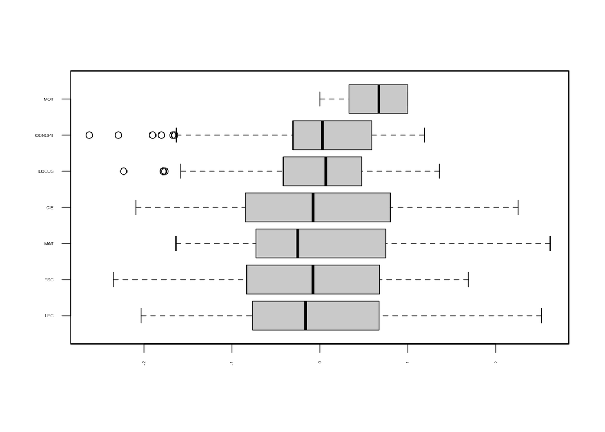

```r
boxplot(paraCluster[,c(varsHabi,varsPsi)],horizontal=T,las=2,cex.axis=0.3)
```

- Tipificado:

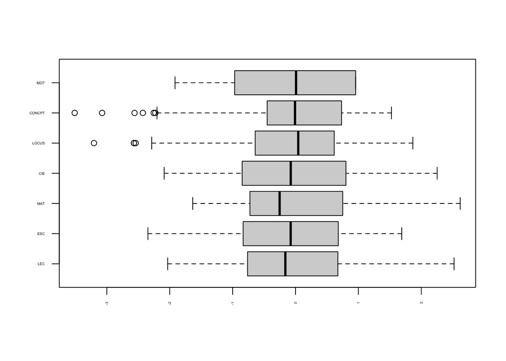

```r
boxplot(scale(paraCluster[,c(varsHabi,varsPsi)]),horizontal=T,las=2,cex.axis=0.3)
```

- Suavizado logarítmicamente:

Usemos el anterior aqui:

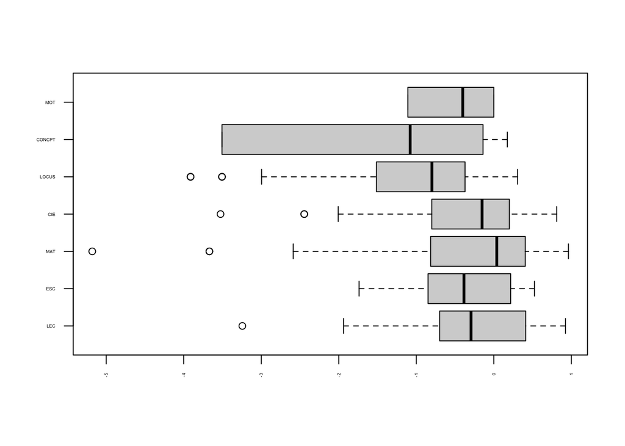

```r
boxplot(log(paraCluster[,c(varsHabi,varsPsi)]),horizontal=T,las=2,cex.axis=0.3)
```

2. Saber cúanto clusters pedir

```r
library(cluster)
set.seed(123)
g.dist = daisy(paraCluster[,], metric="gower")
```

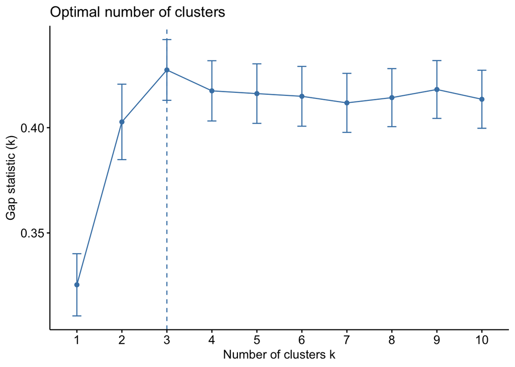

```r
## para PAM
set.seed(123)
library(factoextra)
fviz_nbclust(paraCluster, pam,diss=g.dist,method = "gap_stat",k.max = 10,verbose = F)
```

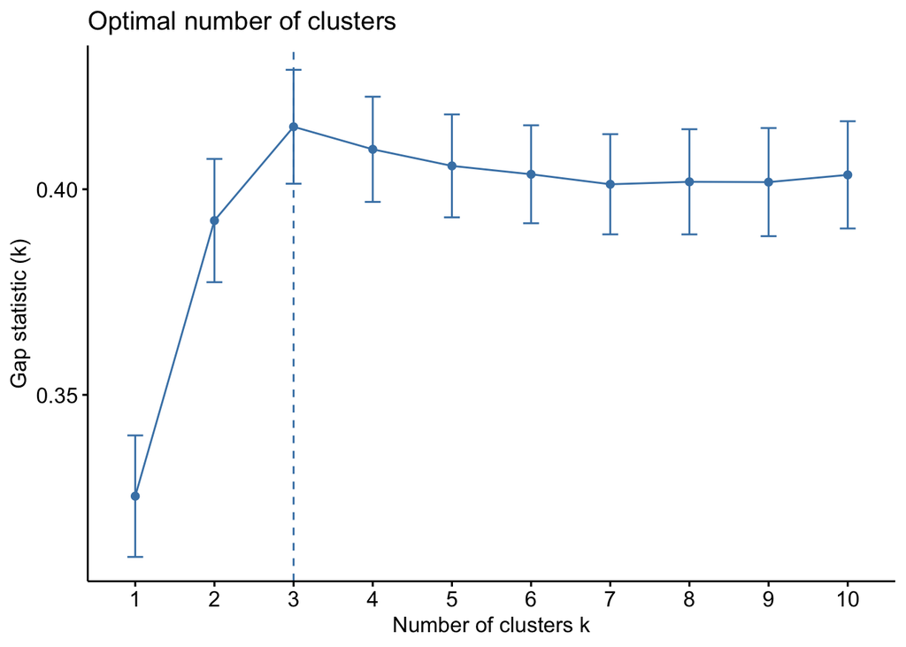

```r
## PARA JERARQUICO
set.seed(123)
fviz_nbclust(paraCluster, hcut,diss=g.dist,method = "gap_stat",k.max = 10,verbose = F,hc_func = "agnes")
```

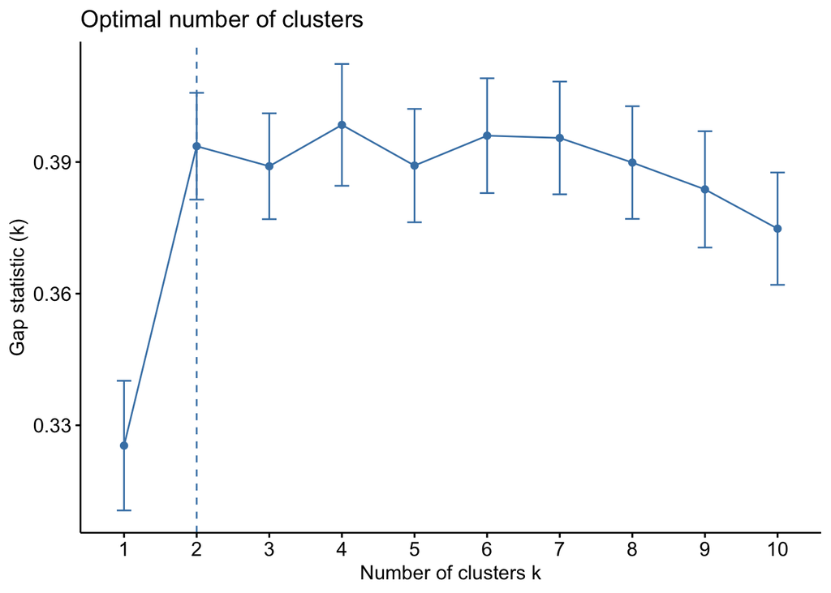

```r
## PARA JERARQUICO
set.seed(123)
fviz_nbclust(paraCluster, hcut,diss=g.dist,method = "gap_stat",k.max = 10,verbose = F,hc_func = "diana")
```

```r
set.seed(123)
SUGERIDOS=3
res.pam=pam(g.dist,k = SUGERIDOS,cluster.only = F)
res.agnes <- hcut(g.dist, k = SUGERIDOS,hc_func='agnes')
res.diana <- hcut(g.dist, k = SUGERIDOS,hc_func='diana')
```

- Evaluemos el resultado usando el coeficiente de *silueta*:
- Un caso se ha clusterizado bien si tiene valor positivo
- Un caso es dificilmente clusterizable si es muy cercano a cero
- Un caso está mal clusterizado si es negativo.

```
##   cluster size ave.sil.width
## 1       1  111          0.24
## 2       2   56          0.28
## 3       3   29          0.30
```

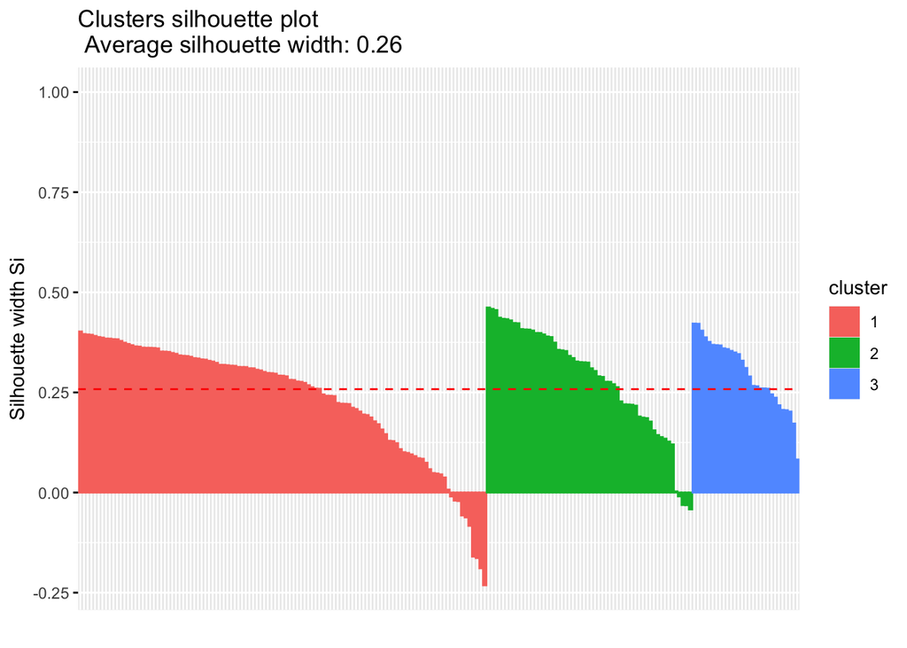

```r
fviz_silhouette(res.pam)
```

```
##   cluster size ave.sil.width
## 1       1   26          0.34
## 2       2  143          0.29
## 3       3   27          0.27
```

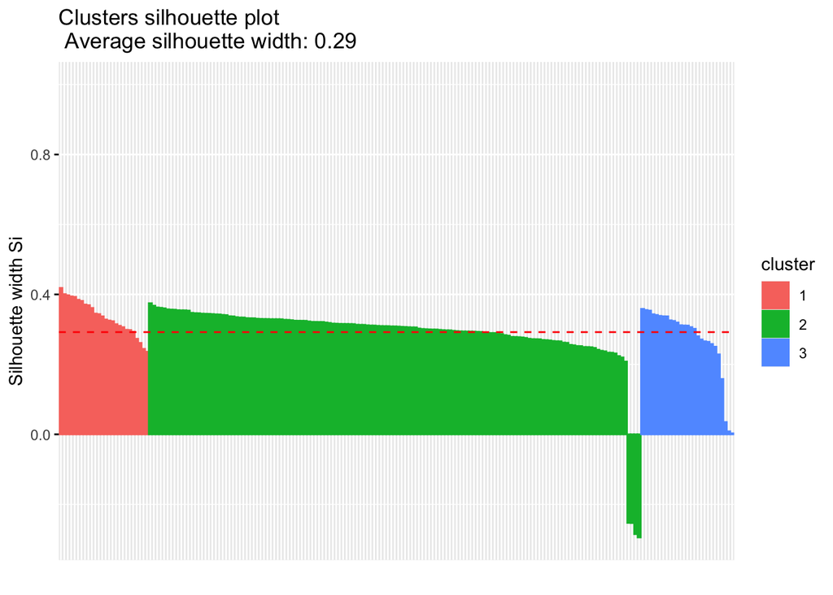

```r
fviz_silhouette(res.agnes)
```

```
##   cluster size ave.sil.width
## 1       1   22          0.39
## 2       2  147          0.28
## 3       3   27          0.14
```

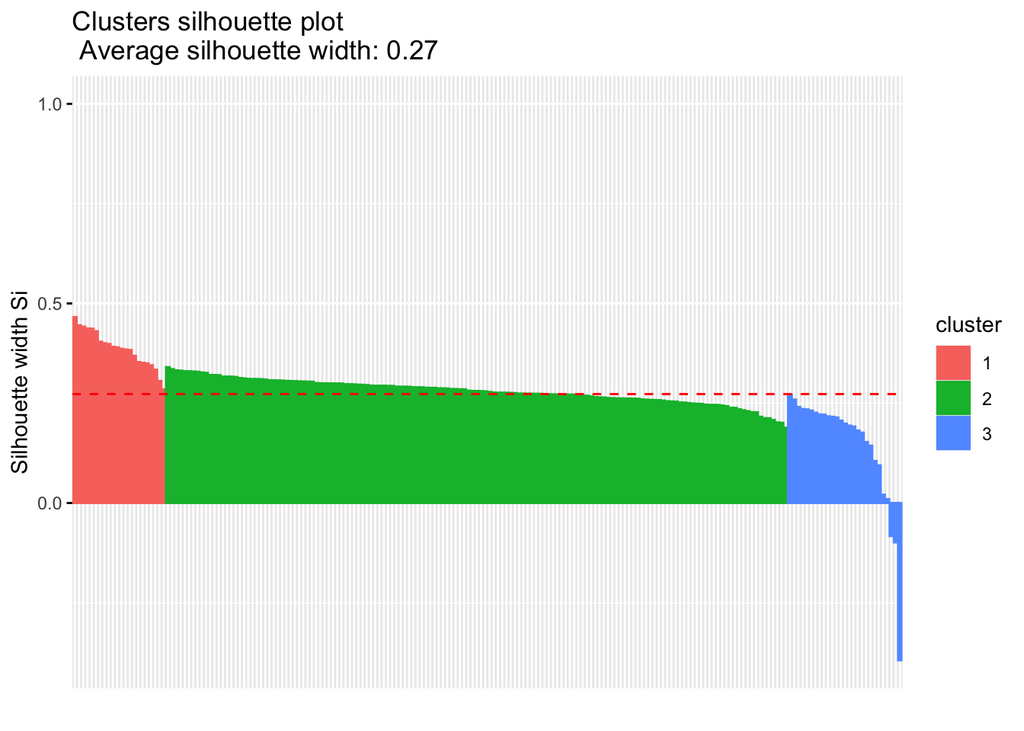

```r
fviz_silhouette(res.diana)
```

## Anexo 2: Exploración de latentes:

1. Calculando matriz de correlación:

```r
# subset para factorial
paraLat=LosDatos[,c(varsHabi,varsRelev,varsPsi)]

# esta es:
library(polycor)
corMatrix=polycor::hetcor(paraLat)$correlations
```

2. Explorar correlaciones:
- Sin evaluar significancia:

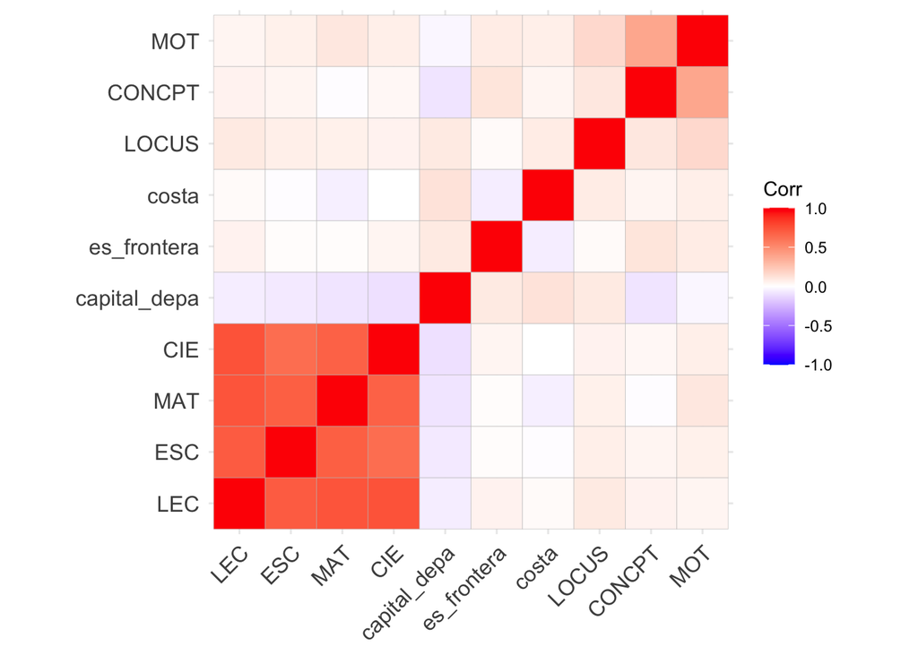

```r
library(ggcorrplot)

ggcorrplot(corMatrix)
```

Si puedes ver bloques correlacionados, hay esperanza de un buen analisis factorial.

3. Verificar si datos permiten factorizar:

```r
library(psych)
psych::KMO(corMatrix)
```

```
## Kaiser-Meyer-Olkin factor adequacy
## Call: psych::KMO(r = corMatrix)
## Overall MSA =  0.79
## MSA for each item =
##          LEC          ESC          MAT          CIE capital_depa  es_frontera
##         0.80         0.87         0.83         0.85         0.54         0.49
##        costa        LOCUS       CONCPT          MOT
##         0.45         0.66         0.50         0.52
```

4. Verificar si la matriz de correlaciones es adecuada

Aqui hay dos pruebas:

- Hnula: La matriz de correlacion es una [matriz identidad](https://en.wikipedia.org/wiki/Identity_matrix)

```r
cortest.bartlett(corMatrix,n=nrow(paraLat))$p.value>0.05
```

```
## [1] FALSE
```

- Hnula: La matriz de correlacion es una [matriz singular](http://mathworld.wolfram.com/SingularMatrix.html).

```r
library(matrixcalc)

is.singular.matrix(corMatrix)
```

```
## [1] FALSE
```

5. Determinar en cuantos factores o variables latentes podríamos redimensionar la data:

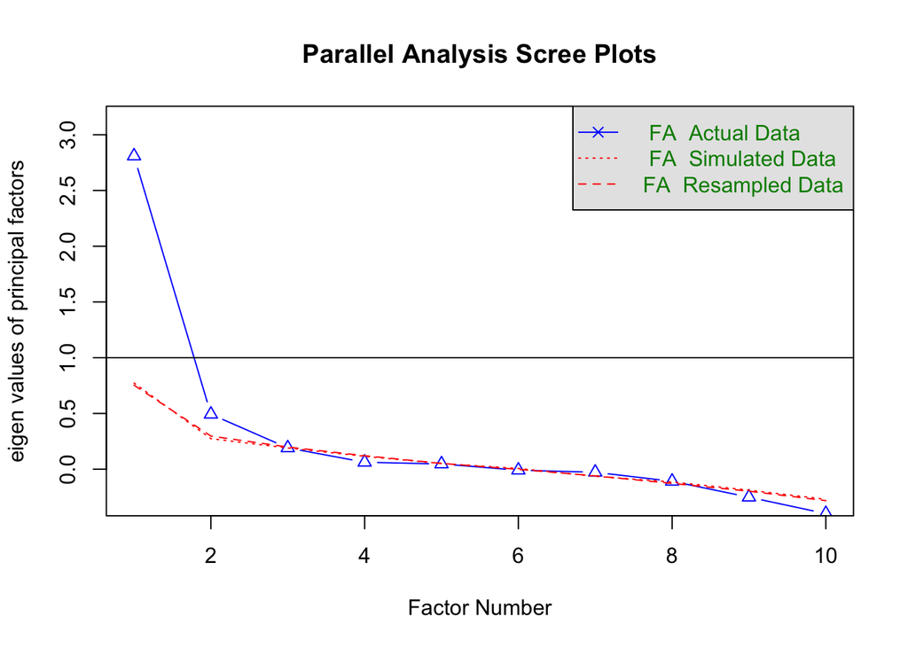

```
## Parallel analysis suggests that the number of factors =  2  and the number of components =  NA
```

```r
fa.parallel(paraLat,fm = 'ML', fa = 'fa',correct = T)
```

Se sugiere 2; pero esperabamos 3. Tratemos 3.

6. Redimensionar a numero menor de factores
- Resultado inicial:

```r
library(GPArotation)
resfa <- fa(paraLat,
            nfactors = 3,
            cor = 'mixed',
            rotate = "varimax",
            fm="minres")
```

```r
print(resfa$loadings)
```

```
##
## Loadings:
##              MR1    MR2    MR3
## LEC           0.886
## ESC           0.792
## MAT           0.840
## CIE           0.812
## capital_depa -0.155 -0.402  0.908
## es_frontera          0.109  0.213
## costa                       0.237
## LOCUS                       0.205
## CONCPT               0.962  0.263
## MOT                  0.169
##
##                  MR1   MR2   MR3
## SS loadings    2.809 1.140 1.047
## Proportion Var 0.281 0.114 0.105
## Cumulative Var 0.281 0.395 0.500
```

- Resultado mejorado (solo apropiado si hay más de un factor):

```r
print(resfa$loadings,cutoff = 0.15)
```

```
##
## Loadings:
##              MR1    MR2    MR3
## LEC           0.886
## ESC           0.792
## MAT           0.840
## CIE           0.812
## capital_depa -0.155 -0.402  0.908
## es_frontera                 0.213
## costa                       0.237
## LOCUS                       0.205
## CONCPT               0.962  0.263
## MOT                  0.169
##
##                  MR1   MR2   MR3
## SS loadings    2.809 1.140 1.047
## Proportion Var 0.281 0.114 0.105
## Cumulative Var 0.281 0.395 0.500
```

- Resultado visual:

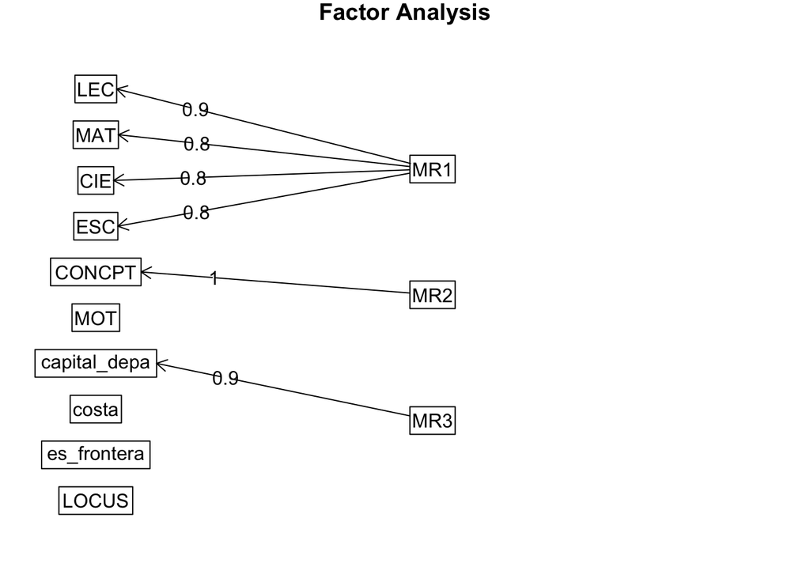

```r
fa.diagram(resfa)
```

Reintentemos, con menos columnas:

```r
resfa <- fa(paraLat[,c(varsHabi,varsPsi)],
            nfactors = 2,
            cor = 'mixed',
            rotate = "varimax",
            fm="minres")
print(resfa$loadings)
```

```
##
## Loadings:
##        MR1    MR2
## LEC     0.881  0.116
## ESC     0.790
## MAT     0.840
## CIE     0.809
## LOCUS          0.185
## CONCPT         0.550
## MOT            0.253
##
##                  MR1   MR2
## SS loadings    2.766 0.429
## Proportion Var 0.395 0.061
## Cumulative Var 0.395 0.456
```

Nuevo Resultado visual:

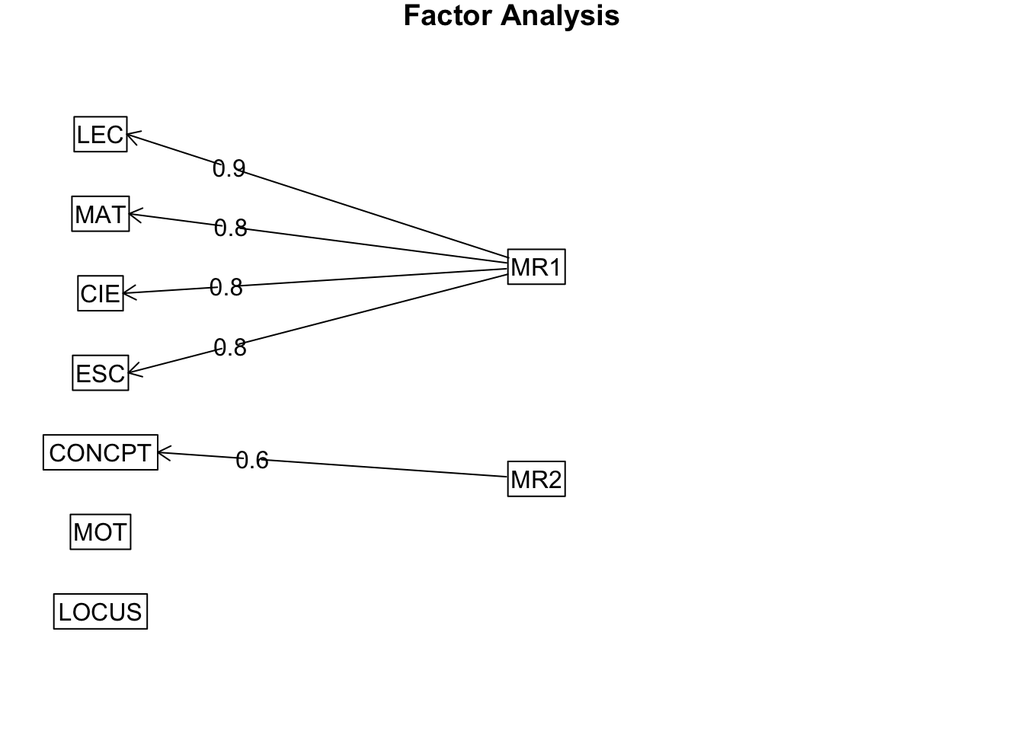

```r
fa.diagram(resfa)
```

7. Evaluando Resultado obtenido:

- ¿Qué variables aportaron mas a los factores?

```r
sort(resfa$communality)
```

```
##      LOCUS        MOT     CONCPT        ESC        CIE        MAT        LEC
## 0.03822390 0.06428565 0.30310581 0.63330626 0.65979886 0.70721096 0.78920954
```

- ¿Qué variables contribuyen a mas de un factor?

```r
sort(resfa$complexity)
```

```
##      MOT      MAT   CONCPT      CIE      ESC      LEC    LOCUS
## 1.000755 1.002182 1.002434 1.016950 1.027037 1.034653 1.238737
```

La exploración no da soporte a tres latentes. Para no afectar la teoría, sólo usaremos dos, pero “MOT” y “LOC” no están cargando mucho en la latente.